# Bootstrap-enhanced DGE analysis

Yifan Yang

The Bootstrap-enhanced DGE analysis is a specialized statistical method developed for Differential Gene Expression (DGE) analysis. It aims to address the limitations inherent in existing DGE tools. Specifically, parametric methods like edgeR and DESeq2 perform well with small sample sizes but tend to produce higher false discovery rates as the sample size grows (n>=8). Conversely, non-parametric methods like the Wilcoxon rank-sum test lack power when the sample size is small (n<8).

## Methodology

The Bootstrap-enhanced DGE analysis starts with *expression matrix* which each row represents an expression feature (either a gene or transcript), and each column pertains to a distinct sample.

### Processing pipelines

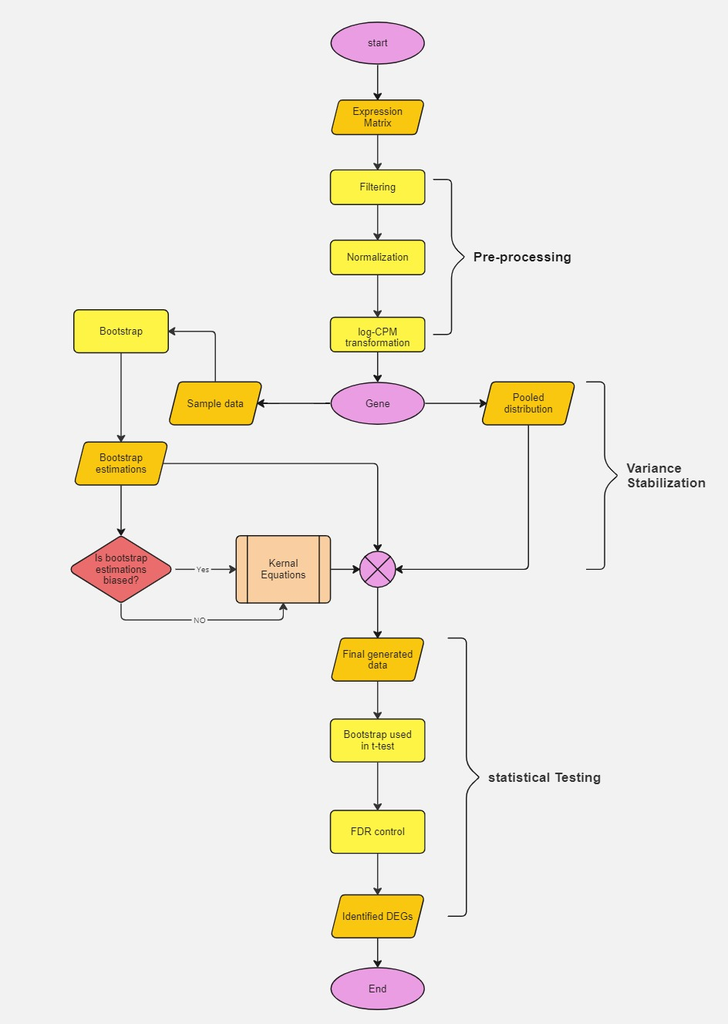

Flow chart of proposed methodology

### Kernel Equations

The selection of kernel equations combine the knowledge of resampled data and pooled distribution to get better estimation of ‘true’ data.

- *The selection of kernel equation cannot be displayed due to private concerns*

## Results

### Real-world datasets

Due to the inherent characteristics of real-world data where the true results are unknown, we utilized the approach suggested in DESeq2.

> We divided the full dataset into an evaluation set (consisting of samples with a sample size of 3) and a verification set (comprising the remaining samples). The accuracy of the algorithms will be assessed by comparing the results obtained from the evaluation set with those from the verification set.

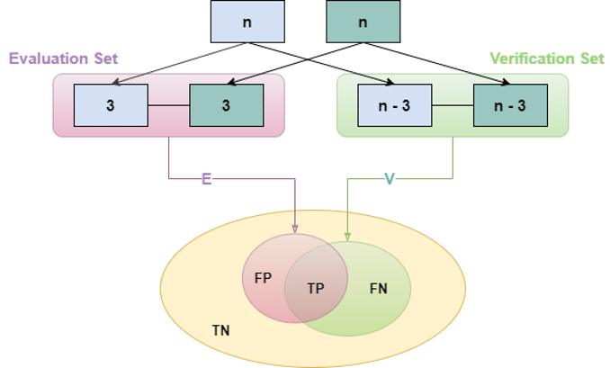

The scheme used in evaluation of real-world dataset

Related criteria used in evaluation:

1. Power (power = $1- \beta$ = P (Reject $H_0$ | $H_0$ is false))
2. false positive rate (FPR=P (Reject $H_0$ | $H_0$ is true))

#### Selected results

On trastuzumab datasets (identify DEGs between control and treatment groups)

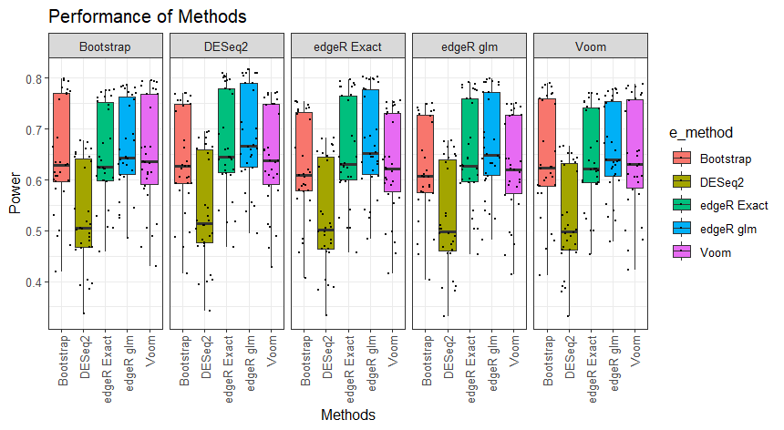

The boxplots in the figures depict the power results obtained from 30 evaluation runs, where algorithm’s power in the evaluation set (box plots) is determined by comparing its performance with the results of each other algorithm in the verification set (grey panels).

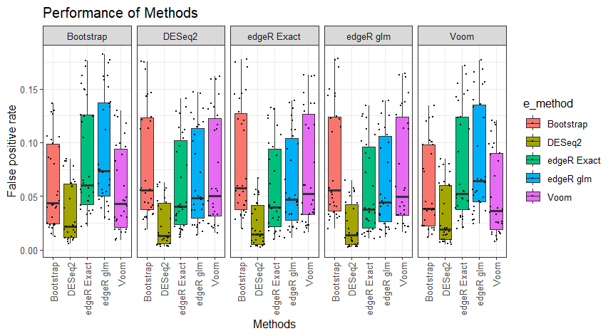

## Reference

Robinson, M. D., McCarthy, D. J., & Smyth, G. K. (2010). edgeR: a Bioconductor package for differential expression analysis of digital gene expression data. Bioinformatics (Oxford, England), 26(1), 139–140. https://doi.org/10.1093/bioinformatics/btp616IF: 5.8 Q1

Love, M.I., Huber, W. & Anders, S. Moderated estimation of fold change and dispersion for RNA-seq data with DESeq2. Genome Biol 15, 550 (2014). https://doi.org/10.1186/s13059-014-0550-8

Law, C.W., Chen, Y., Shi, W. et al. voom: precision weights unlock linear model analysis tools for RNA-seq read counts. Genome Biol 15, R29 (2014). https://doi.org/10.1186/gb-2014-15-2-r29